# Homework 3

Philipp Ross

June 21 2015

### Running fastqc on three datasets

When running fastqc I used the *–nogroup* flag in order to prevent binning of basepairs along the read lengths. In addition each dataset downloaded consists of paired end reads.

#### Zaire ebolavirus genome sequencing from 2014 outbreak in Sierra Leone

To download this data I used the following command(s):

```bash
$ fastq-dump --split-files SRR1553610
Read 219837 spots for SRR1553610
Written 219837 spots for SRR1553610
```

When looking at the SRA run description it says that we’re looking at data derived from RNA, which is important to note because that type of data contains its own biases relative to other types of sequencing data which one can see within the QC reports. This should also make sense considering the ebolavirus contains one single stranded negative-sense RNA-based genome. The data was also generated on an Illumina HiSeq 2500.

If we look at the pre base sequence quality of both paired files respectively we see some data that looks alright and some data that looks potentially pretty bad.

**SRR1553610_1**

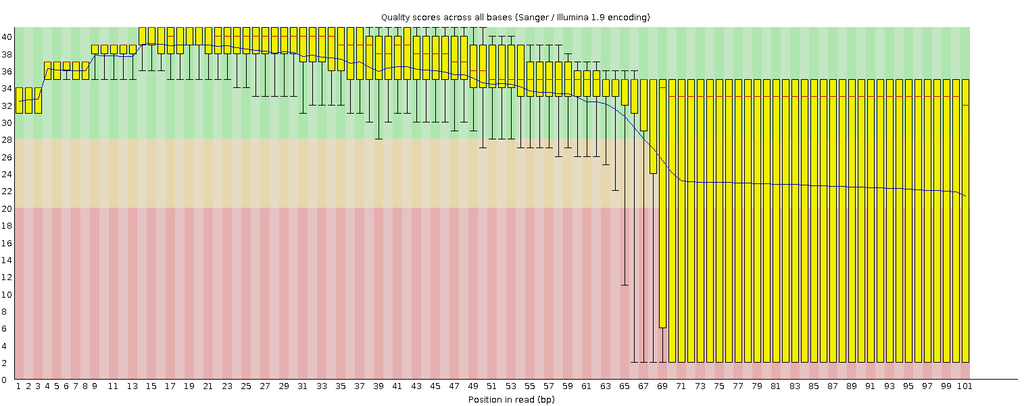

**SRR1553610_2**

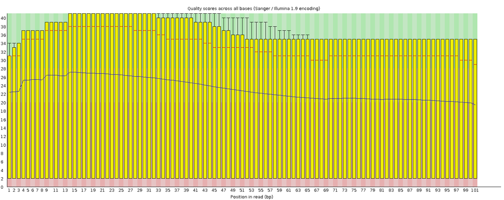

What see in the first paired file is what one normally sees in a decent quality run. You see the quality stay above a phred score of 30 and then drop of as the length increases.

However, if we look at the second paired file, the quality per base is all over the place. What this is saying is that there are some reads that contain very poor or ambiguous base calls along the entire read length. Looking at the per base N content section tells us these aren’t ambiguous calls but just base calls of very low quality.

Next let’s look at the per base sequence content for both files.

**SRR1553610_1**

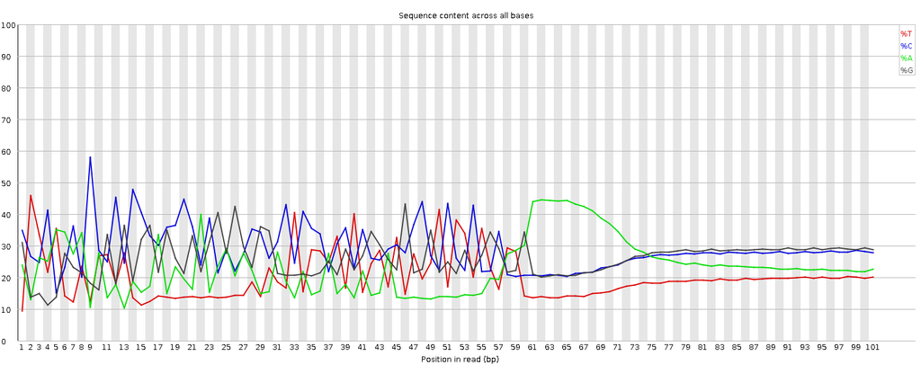

**SRR1553610_2**

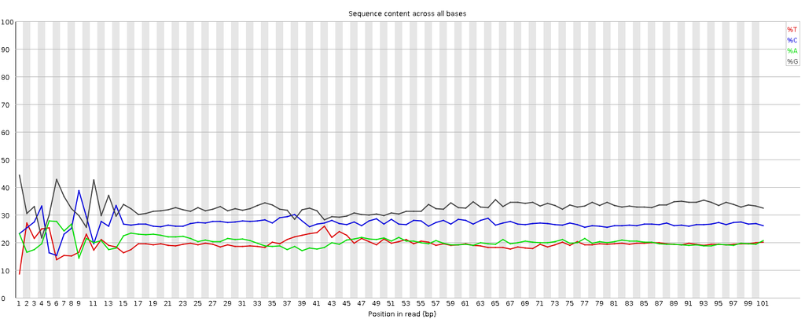

When performing RNA-seq it’s common to see a fluctuation like what you see in the second paired read file where the first 5-10 bases exhibit a predictable fluctuation. This is due to the nonrandom primers used to reverse transcribe RNA into cDNA before sequencing and it’s debated whether or not it’s best to trim those base pairs or not in order to improve alignment accuracy.

However, when looking at the first paired read file that fluctuation extends much further into the reads than can be explained by nonrandom priming. What could be happening is that, although fastqc didn’t detect any there could still be some type of adapter contamination on the 5’ end of each read.

In addition while the fluctuations disappear at about the 60th base pair, the sequence content does not at up to the base pair distribution seen within the ebola genome which is actually more AT rich than it is GC rich, meaning that we could be looking at some type of additional contamination - most likely human DNA.

#### Whole genome sequencing of Plasmodium vivax

To download this data I used the following command(s) and received the following error:

```bash
$ fastq-dump --split-files -X 100000 SRR332573
2015-06-23T18:02:04 fastq-dump.2.3.5 err: binary large object corrupt while reading binary large object within virtual database module - failed SRR332573

=============================================================
An error occurred during processing.
A report was generated into the file '/root/ncbi_error_report.xml'.
If the problem persists, you may consider sending the file
to 'sra@ncbi.nlm.nih.gov' for assistance.
=============================================================
```

When I look in my current directory I can see some of it was downloaded but not all of it…

```bash
$ ll
total 648M
-rw-r--r-- 1 1000 staff  58M Jun 23 17:25 SRR1553610_1.fastq
-rw-r--r-- 1 1000 staff  58M Jun 23 17:25 SRR1553610_2.fastq
-rw-r--r-- 1 1000 staff  16M Jun 23 18:02 SRR332573_1.fastq
-rw-r--r-- 1 1000 staff  16M Jun 23 18:02 SRR332573_2.fastq
-rw-r--r-- 1 1000 staff  31M Jun 23 18:03 SRR340134_1.fastq
-rw-r--r-- 1 1000 staff  31M Jun 23 18:03 SRR340134_2.fastq
-rw-r--r-- 1 1000 staff 220M Jun 16 03:50 SRR519926_1.fastq
-rw-r--r-- 1 1000 staff 323K Jun 16 03:53 SRR519926_1_fastqc.html
-rw-r--r-- 1 1000 staff 381K Jun 16 03:53 SRR519926_1_fastqc.zip
-rw-r--r-- 1 1000 staff 220M Jun 16 03:50 SRR519926_2.fastq
-rw-r--r-- 1 1000 staff 306K Jun 16 03:53 SRR519926_2_fastqc.html
-rw-r--r-- 1 1000 staff 349K Jun 16 03:53 SRR519926_2_fastqc.zip
```

Checking the file with less shows that ~10,000 spots are reads containing exclusively N’s, meaning an ambiguous base call. The end of the file ended up being reads exclusively containing A’s.

To download this data I used the following command(s):

```bash
$ fastq-dump --split-files -X 100000 SRR340134
Read 100000 spots for SRR340134
Written 100000 spots for SRR340134
```

According to the SRA description we’re looking at 100bp paired end whole genome sequencing done on an Illumina HiSeq 2000.

If we look at the duplication levels for each read within the pair, we can see that there is a decent amount of duplication occuring. If we deduplicated the reads based simply on the nucleotide content of the reads we would remove ~15% of the reads from each file! That most likely has to do with the number of reads containing only N’s.

**SRR340134_1**

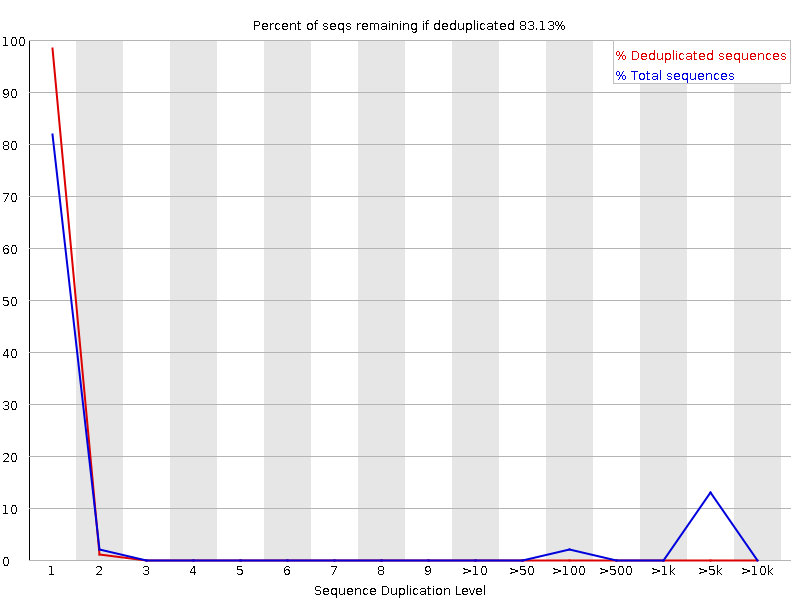

**SRR340134_2**

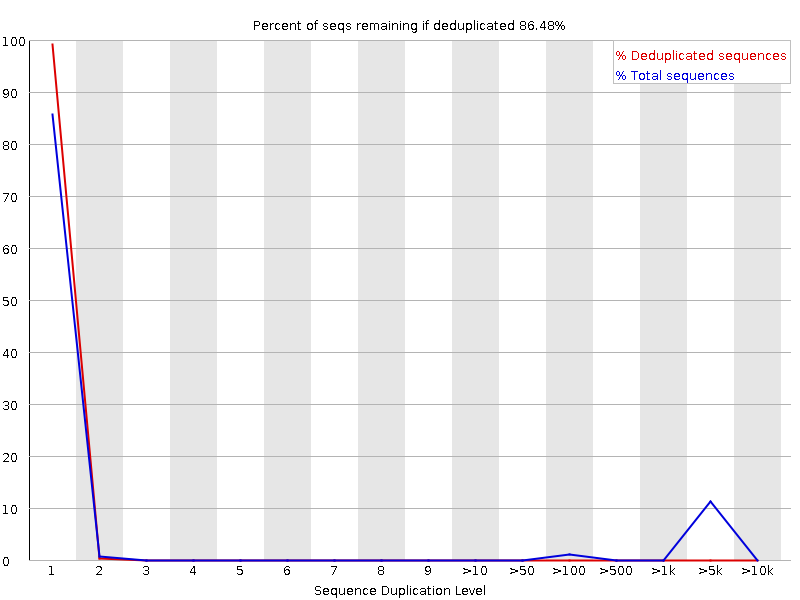

In the following two plots I’m not entirely sure what’s going on. If we look at the [FastQC documentation](http://www.bioinformatics.babraham.ac.uk/projects/fastqc/Help/3%20Analysis%20Modules/5%20Per%20Sequence%20GC%20Content.html) it tells us that it uses the observed data to build a model distribution. I’m assuming again that the long strings of N’s within the read files is causing a problem in predicting an accurate theoretical distribution. We can see, however, in the actual GC count per read, that we have a peak around where we would expect the GC content to be for Plasmodium vivax.

**SRR340134_1**

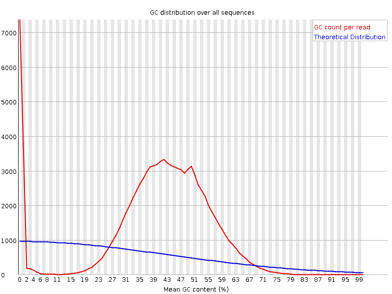

**SRR340134_2**

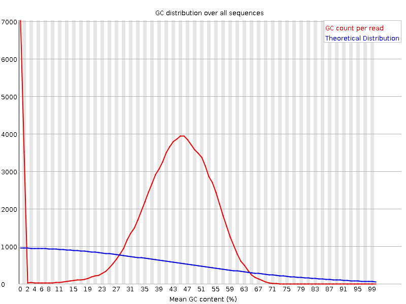

#### Whole genome sequencing of Plasmodium knowlesi

To download this data I used the following command:

```bash
$ fastq-dump --split-files -X 100000 ERR366425
Read 100000 spots for ERR366425
Written 100000 spots for ERR366425
```

According to the SRA description, we should be looking at 150 bp paired-end whole genome sequencing reads that were run on an Illumina MiSeq.

Looking through the FastQC report, the quality of the data looks very good. Almost all of the tests are marked as passed except for per base sequence quality plots but that’s only because toward the end of the 150 bp reads the quality starts to dip into the “red” area marked as poor quality but the rest of the read stays above a score of 28. I want to look at the only other two plots tha raised warnings.

The per base sequence content raised warnings for both reads within the pair. However, because Plasmodium knowlesi is known to have a biased genome relative to its nucleotide distribution this isn’t surprising. The distribution of nucleotides stays constant from the beginning to the end of the reads so there’s no indication of contamination either.

**ERR366425_1**

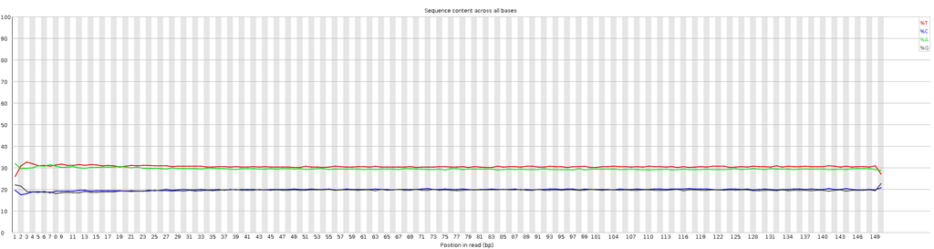

**ERR366425_2**

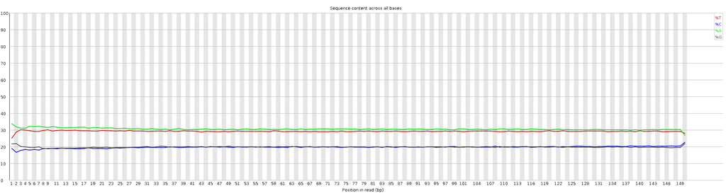

Finally, the kmer profiles plot also raised warnings. These plots are notoriously hard to analyze so I looked to the [documentation](http://www.bioinformatics.babraham.ac.uk/projects/fastqc/Help/3%20Analysis%20Modules/11%20Kmer%20Content.html) for help.

**ERR366425_1**

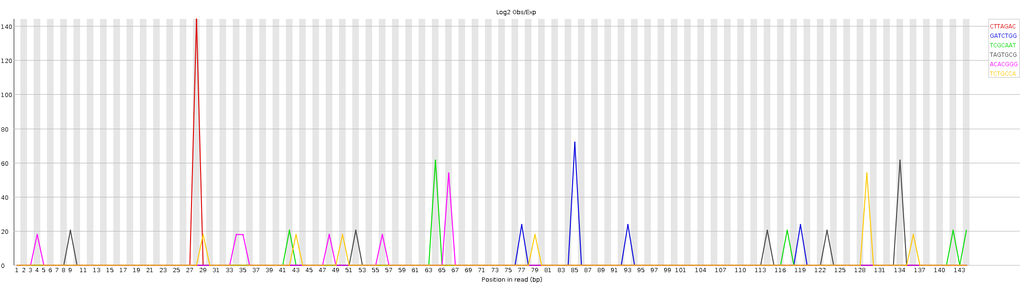

**ERR366425_2**

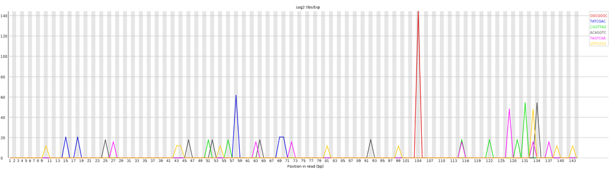

### Which data indicates a good quality run and which data indicates a poor quality run?

An example of **a good quality run** can be seen in the whole genome sequencing of Plasmodium knowlesi. The per base sequence quality in the second read pair file shows that there’s a slight decline in quality at the read nears the 130 base pair mark. But even if we were to trim every read by 20 base pairs from the 3’ end you would still be left with 130 base pairs to use to align to some place in the genome which is still a very strong candidate for finding a unique match. The other flags are only warnings - one of them being for for base sequence content but this can be easily explained with a minimal understanding of the Plasmodium knowlesi genome in which there is a significant AT bias, which goes against the assumptions of fastqc.

An example of **a poor quality run** (especially relative to the knowlesi sequencing run) is the vivax whole genome sequencing run under SRR340134. The thing to take into consideration is that I only downloaded the first 100,000 reads so there may be a lot more data within the rest of the file that doesn’t skew the results as much as what you can see in the QC report. But within both read pair files you can see the quality scores drop off significantly about 50-60 base pairs into the reads for the first paired file while in the second paired file you see quality drop off within only 15 base pairs! In fact the quality of each base pair after 45 base pairs into each read is essentially 0. And according to the sequence length distribution plot each read is made up of 100 base pair length reads. So the second read pair file is essentially useless…